# Apollo ST310 Group Project

21-03-2023

# Import libraries

```r
knitr::opts_chunk$set(echo = TRUE)
library(ggplot2)
library(GGally)
library(yardstick)
library(tidymodels)
library(skimr)
library(ranger)
library(vip)
```

# EDA & Data Manipulation

## Import data

```r
# Import and view head of training data
path <- "../Data/Stellar-Classification-Dataset.csv"
raw_df <- read.csv(path)
```

Overview of the raw data:

```r
raw_df <- raw_df[,c(14,1:13, 15:ncol(raw_df))]
head(raw_df)
```

```
##    class      obj_ID    alpha      delta        u        g        r        i
## 1 GALAXY 1.23766e+18 135.6891 32.4946318 23.87882 22.27530 20.39501 19.16573
## 2 GALAXY 1.23766e+18 144.8261 31.2741849 24.77759 22.83188 22.58444 21.16812
## 3 GALAXY 1.23766e+18 142.1888 35.5824442 25.26307 22.66389 20.60976 19.34857
## 4 GALAXY 1.23766e+18 338.7410 -0.4028276 22.13682 23.77656 21.61162 20.50454
## 5 GALAXY 1.23768e+18 345.2826 21.1838656 19.43718 17.58028 16.49747 15.97711
## 6    QSO 1.23768e+18 340.9951 20.5894763 23.48827 23.33776 21.32195 20.25615
##          z run_ID rerun_ID cam_col field_ID spec_obj_ID  redshift plate   MJD
## 1 18.79371   3606      301       2       79 6.54378e+18 0.6347936  5812 56354
## 2 21.61427   4518      301       5      119 1.17601e+19 0.7791360 10445 58158
## 3 18.94827   3606      301       2      120 5.15220e+18 0.6441945  4576 55592
## 4 19.25010   4192      301       3      214 1.03011e+19 0.9323456  9149 58039
## 5 15.54461   8102      301       3      137 6.89186e+18 0.1161227  6121 56187
## 6 19.54544   8102      301       3      110 5.65898e+18 1.4246590  5026 55855
##   fiber_ID
## 1      171
## 2      427
## 3      299
## 4      775
## 5      842
## 6      741
```

## Distribution of `class`

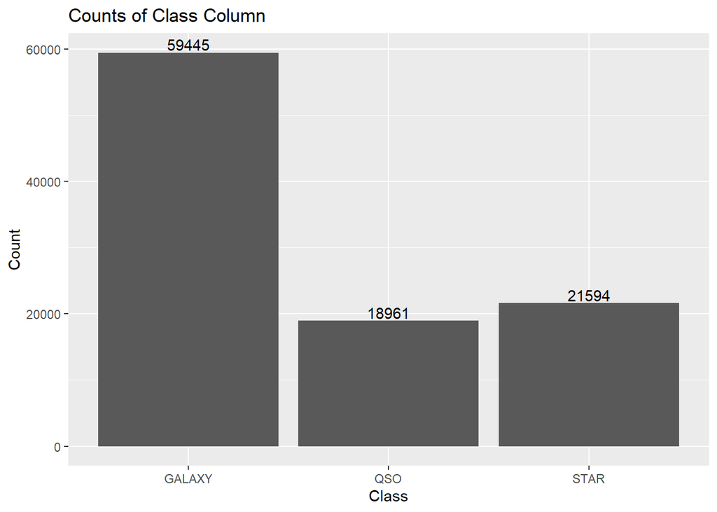

```r
ggplot(raw_df,aes(x=factor(class))) +
geom_bar() +
labs(title="Counts of Class Column", x="Class", y = "Count")+
geom_text(aes(label=..count..),stat='count', vjust=-0.2)
```

## Re-labelling `class`

The distribution of classes is quite uneven, so since we want to use binary classification we combine the two smaller classes into one larger `OTHER` class.

```r
raw_df[raw_df == 'QSO' | raw_df == 'STAR'] <- 'OTHER'
```

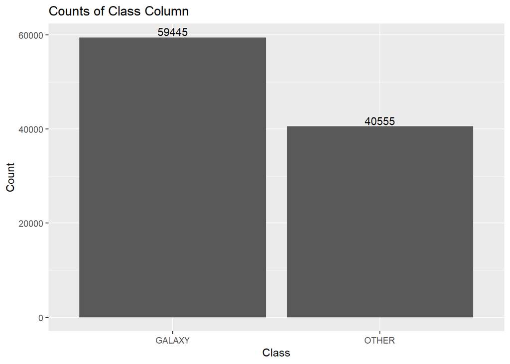

```r
ggplot(raw_df,aes(x=factor(class))) +
geom_bar() +
labs(title="Counts of Class Column", x="Class", y = "Count")+
geom_text(aes(label=..count..),stat='count', vjust=-0.2)
```

## Subsample the data

Since the class sizes are still quite uneven, we subsample the data to get even class sizes.

```r
# Filter the data by class and subsample
galaxy_df <- raw_df[raw_df$class == "GALAXY", ]
subsampled_galaxy_df <- galaxy_df[sample(nrow(galaxy_df), size = 40000, replace = FALSE),]

other_df <- raw_df[raw_df$class == "OTHER", ]
subsampled_other_df <- other_df[sample(nrow(other_df), size = 40000, replace = FALSE),]
```

```r
# Create new DataFrame
df <- rbind(subsampled_galaxy_df, subsampled_other_df)
dim(df)
```

```
## [1] 80000    18
```

Updated plot of rebalanced classes

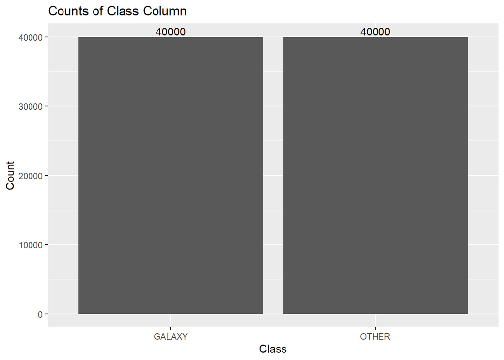

```r
ggplot(df,aes(x=factor(class))) +
geom_bar() +
labs(title="Counts of Class Column", x="Class", y = "Count")+
geom_text(aes(label=..count..),stat='count', vjust=-0.2)
```

## Summary statistics

```r
df %>%
  skimr::skim(colnames(df))
```

Data summary

| Name | Piped data |
| --- | --- |
| Number of rows | 80000 |
| Number of columns | 18 |
| _______________________ |  |
| Column type frequency: |  |
| character | 1 |
| numeric | 17 |
| ________________________ |  |
| Group variables | None |

**Variable type: character**

| skim_variable | n_missing | complete_rate | min | max | empty | n_unique | whitespace |
| --- | --- | --- | --- | --- | --- | --- | --- |
| class | 0 | 1 | 5 | 6 | 0 | 2 | 0 |

**Variable type: numeric**

| skim_variable | n_missing | complete_rate | mean | sd | p0 | p25 | p50 | p75 | p100 | hist |
| --- | --- | --- | --- | --- | --- | --- | --- | --- | --- | --- |
| obj_ID | 0 | 1 | 1.237688e+18 | 2.335530e+14 | 1.23765e+18 | 1.23766e+18 | 1.23766e+18 | 1.237670e+18 | 1.24000e+18 | ▇▁▁▁▁ |
| alpha | 0 | 1 | 1.777400e+02 | 9.698000e+01 | 1.00000e-02 | 1.26670e+02 | 1.80960e+02 | 2.347800e+02 | 3.60000e+02 | ▅▅▇▅▃ |
| delta | 0 | 1 | 2.427000e+01 | 1.971000e+01 | -1.87900e+01 | 5.17000e+00 | 2.39500e+01 | 4.023000e+01 | 8.30000e+01 | ▅▇▇▅▁ |
| u | 0 | 1 | 2.184000e+01 | 3.550000e+01 | -9.99900e+03 | 2.02900e+01 | 2.20100e+01 | 2.354000e+01 | 3.27800e+01 | ▁▁▁▁▇ |
| g | 0 | 1 | 2.044000e+01 | 3.548000e+01 | -9.99900e+03 | 1.89800e+01 | 2.10000e+01 | 2.203000e+01 | 3.16000e+01 | ▁▁▁▁▇ |
| r | 0 | 1 | 1.966000e+01 | 1.850000e+00 | 9.82000e+00 | 1.82100e+01 | 2.01300e+01 | 2.106000e+01 | 2.95700e+01 | ▁▂▇▂▁ |
| i | 0 | 1 | 1.914000e+01 | 1.770000e+00 | 9.47000e+00 | 1.78300e+01 | 1.94500e+01 | 2.049000e+01 | 3.21400e+01 | ▁▃▇▁▁ |
| z | 0 | 1 | 1.872000e+01 | 3.546000e+01 | -9.99900e+03 | 1.75600e+01 | 1.90600e+01 | 2.005000e+01 | 2.93800e+01 | ▁▁▁▁▇ |
| run_ID | 0 | 1 | 4.475280e+03 | 1.970030e+03 | 1.09000e+02 | 3.18000e+03 | 4.18800e+03 | 5.362000e+03 | 8.16200e+03 | ▂▅▇▃▃ |
| rerun_ID | 0 | 1 | 3.010000e+02 | 0.000000e+00 | 3.01000e+02 | 3.01000e+02 | 3.01000e+02 | 3.010000e+02 | 3.01000e+02 | ▁▁▇▁▁ |
| cam_col | 0 | 1 | 3.510000e+00 | 1.590000e+00 | 1.00000e+00 | 2.00000e+00 | 4.00000e+00 | 5.000000e+00 | 6.00000e+00 | ▇▅▅▅▃ |
| field_ID | 0 | 1 | 1.848200e+02 | 1.476100e+02 | 1.10000e+01 | 8.20000e+01 | 1.46000e+02 | 2.390000e+02 | 9.89000e+02 | ▇▃▁▁▁ |
| spec_obj_ID | 0 | 1 | 5.849426e+18 | 3.342189e+18 | 2.99579e+17 | 2.90386e+18 | 5.64196e+18 | 8.388003e+18 | 1.41269e+19 | ▇▇▇▅▂ |
| redshift | 0 | 1 | 6.100000e-01 | 8.000000e-01 | -1.00000e-02 | 0.00000e+00 | 4.10000e-01 | 7.700000e-01 | 7.01000e+00 | ▇▁▁▁▁ |
| plate | 0 | 1 | 5.195220e+03 | 2.968450e+03 | 2.66000e+02 | 2.57900e+03 | 5.01100e+03 | 7.450000e+03 | 1.25470e+04 | ▇▇▇▅▂ |
| MJD | 0 | 1 | 5.562576e+04 | 1.805710e+03 | 5.16080e+04 | 5.43890e+04 | 5.58890e+04 | 5.694700e+04 | 5.89320e+04 | ▃▃▇▇▅ |
| fiber_ID | 0 | 1 | 4.489700e+02 | 2.723700e+02 | 1.00000e+00 | 2.21000e+02 | 4.32000e+02 | 6.430000e+02 | 1.00000e+03 | ▇▇▇▆▅ |

# Model Recipe

## Train/Test Split

Since we have a large dataset we use 80% of the data for training.

```r
set.seed(222)
# Put 80% of the data into the training set
data_split <- initial_split(df, prop = 0.8)

# Create data frames for the two sets:
train_data <- training(data_split)
test_data  <- testing(data_split)
```

## Create our recipe

The dataset contains a lot of ID variable which do not contain useful information such as run_ID which is used to identify that specific scan.

```r
# Declare the ID variables
IDs <- c("obj_ID", "run_ID", "rerun_ID", "cam_col", "field_ID", "spec_obj_ID", "plate", "MJD", "fiber_ID")
```

Next, we create a recipe that applies some pre-processing steps.

```r
# Define our model, and exclude the ID variables
recipe <- train_data %>%
  recipe(class ~ .) %>%
  update_role(all_of(IDs), new_role = "ID") %>% # ID's not treated as predictors
  step_center(all_predictors(), -all_outcomes()) %>% # ensures mean 0
  step_scale(all_predictors(), -all_outcomes()) %>% # ensures standard deviation of 1
  prep()  # applies the pre-processing
```

A summary of which variables are treated as predictors.

```r
# Summary of the recipe
summary(recipe)
```

```
## # A tibble: 18 × 4
##    variable    type    role      source
##    <chr>       <chr>   <chr>     <chr>
##  1 obj_ID      numeric ID        original
##  2 alpha       numeric predictor original
##  3 delta       numeric predictor original
##  4 u           numeric predictor original
##  5 g           numeric predictor original
##  6 r           numeric predictor original
##  7 i           numeric predictor original
##  8 z           numeric predictor original
##  9 run_ID      numeric ID        original
## 10 rerun_ID    numeric ID        original
## 11 cam_col     numeric ID        original
## 12 field_ID    numeric ID        original
## 13 spec_obj_ID numeric ID        original
## 14 redshift    numeric predictor original
## 15 plate       numeric ID        original
## 16 MJD         numeric ID        original
## 17 fiber_ID    numeric ID        original
## 18 class       nominal outcome   original
```

This can then be extracted as follows

```r
train_data <- juice(recipe) # return variables from processed training data
```

We apply the same pre-processing to the test data.

```r
test_data <- recipe %>%
  bake(test_data) # ensures that same pre-processing is used on test data.
```

# Logisitic Regression Model

Since our data set involves classification, we use logistic regression as our baseline model.

```r
# Define our logistic regression model
logistic_model <-
  logistic_reg() %>%
  set_engine("glm")
```

## Workflow

```r
# Create our workflow
logistic_wflow <-
  workflow() %>%
  add_model(logistic_model) %>%
  add_recipe(recipe)

logistic_wflow
```

```
## ══ Workflow ════════════════════════════════════════════════════════════════════
## Preprocessor: Recipe
## Model: logistic_reg()
##
## ── Preprocessor ────────────────────────────────────────────────────────────────
## 2 Recipe Steps
##
## • step_center()
## • step_scale()
##
## ── Model ───────────────────────────────────────────────────────────────────────
## Logistic Regression Model Specification (classification)
##
## Computational engine: glm
```

## Fit and explore the model

We create a a fitted model by appling the workflow.

```r
# Fit the model
logistic_fit <-
  logistic_wflow %>%
  fit(data = train_data)
```

The fitted values from our model.

```r
logistic_fit %>%
  extract_fit_parsnip() %>%
  tidy()
```

```
## # A tibble: 9 × 5
##   term        estimate std.error statistic   p.value
##   <chr>          <dbl>     <dbl>     <dbl>     <dbl>
## 1 (Intercept)   0.263     0.0120     21.9  1.17e-106
## 2 alpha        -0.0126    0.0101     -1.24 2.14e-  1
## 3 delta         0.0918    0.0100      9.14 6.11e- 20
## 4 u             1.88      0.430       4.38 1.19e-  5
## 5 g           -74.6       1.25      -59.8  0
## 6 r             1.89      0.0946     19.9  1.98e- 88
## 7 i             1.45      0.0856     17.0  1.14e- 64
## 8 z             4.03      1.16        3.47 5.12e-  4
## 9 redshift      0.217     0.0133     16.4  2.77e- 60
```

Apply this fit to our test data

```r
logistic_augment <-
  augment(logistic_fit, test_data, type = "prob")
```

## Predictions

Created predicted values and probabilities

```r
# DataFrame of prediction probabilities
pred_df <- logistic_augment %>%
  select(class, .pred_class, .pred_GALAXY)
```

```r
head(pred_df)
```

```
## # A tibble: 6 × 3
##   class  .pred_class .pred_GALAXY
##   <fct>  <fct>              <dbl>
## 1 GALAXY OTHER              0.443
## 2 GALAXY OTHER              0.248
## 3 GALAXY GALAXY             0.885
## 4 GALAXY GALAXY             0.884
## 5 GALAXY GALAXY             0.622
## 6 GALAXY GALAXY             0.767
```

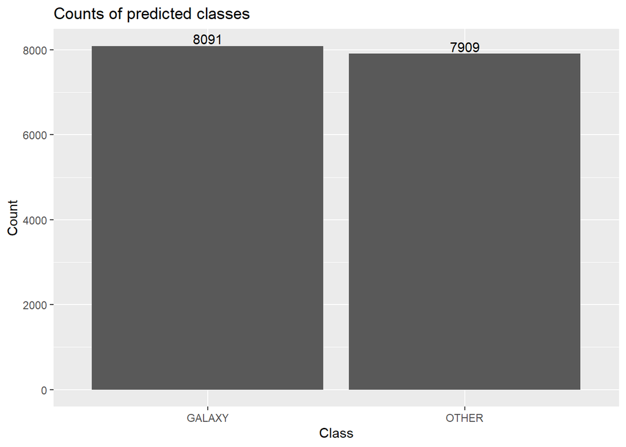

```r
# Distribution of predictions
ggplot(pred_df,aes(x=factor(class))) +
geom_bar() +
labs(title="Counts of predicted classes", x="Class", y = "Count")+
geom_text(aes(label=..count..),stat='count', vjust=-0.2)
```

## Evaluation of Model

The main two metrics that we will use to compare our models are ROC/AUC and accuracy.

### Evaluation metric: ROC/AUC

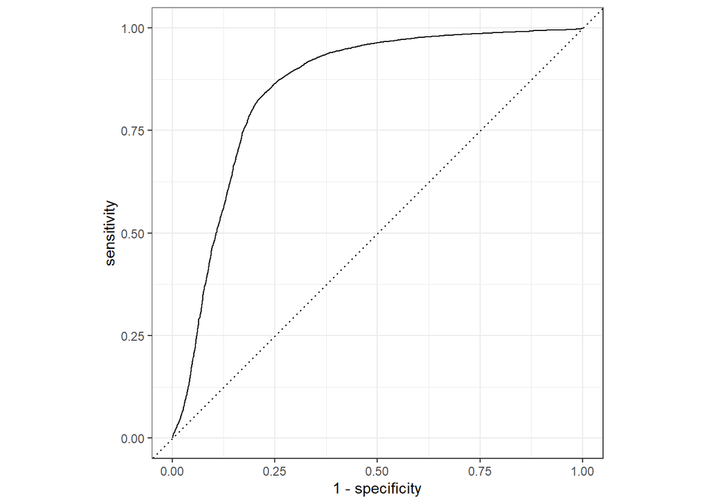

```r
logistic_augment %>%
  roc_curve(truth = as.factor(class), .pred_GALAXY) %>%
  autoplot()
```

```r
# Area Under Curve (AUC)
logistic_augment %>%
  roc_auc(truth = as.factor(class), .pred_GALAXY)
```

```
## # A tibble: 1 × 3
##   .metric .estimator .estimate
##   <chr>   <chr>          <dbl>
## 1 roc_auc binary         0.853
```

### Confusion Matrix

```r
conf_mat(pred_df, truth=class, estimate=.pred_class)
```

```
##           Truth
## Prediction GALAXY OTHER
##     GALAXY   6483  1547
##     OTHER    1608  6362
```

### Evaluation Metric: Accuracy Score

```r
accuracy(pred_df, as.factor(class), as.factor(.pred_class))
```

```
## # A tibble: 1 × 3
##   .metric  .estimator .estimate
##   <chr>    <chr>          <dbl>
## 1 accuracy binary         0.803
```

For our baseline logistic regression, we get a misclassification rate of approximately 20%. This will be used compare with the later models.